# Project 456_1

Minh Le

2/11/2022

## Introduction

```r
library(tidyverse)
library(lubridate)
library(caret)
```

## Data description

Load dataset

```r
stock <- stock <- read.csv("stock_return.csv", sep = "", dec = ".")
head(stock)
```

```
##       Date   ATT ATT.PctChg.1 Microsoft Microsoft.PctChg.1 Nordstrom
## 1 4/1/2010 20.12        35.18     37.34            1186.69        NA
## 2 5/3/2010 18.76       -6.76%     34.61             -1.62%     36.05
## 3 6/1/2010 18.67       -0.48%     33.89             -2.08%     29.23
## 4 7/1/2010 20.37        9.11%     34.66              2.27%     30.88
## 5 8/2/2010 21.23        4.22%     32.76             -5.48%     26.44
## 6 9/1/2010 22.46        5.79%     38.24             16.73%     34.01
##   Nordstrom.PctChg.1  SP_500 SP_500.PctChg.1
## 1                         NA
## 2             -3.45% 1089.41          -8.20%
## 3            -18.92% 1030.71          -5.39%
## 4              5.64% 1101.60           6.88%
## 5            -14.38% 1049.33          -4.74%
## 6             28.63% 1141.20           8.76%
```

```r
str(stock)
```

```
## 'data.frame':    60 obs. of  9 variables:
##  $ Date              : chr  "4/1/2010" "5/3/2010" "6/1/2010" "7/1/2010" ...
##  $ ATT               : num  20.1 18.8 18.7 20.4 21.2 ...
##  $ ATT.PctChg.1      : chr  "35.18" "-6.76%" "-0.48%" "9.11%" ...
##  $ Microsoft         : num  37.3 34.6 33.9 34.7 32.8 ...
##  $ Microsoft.PctChg.1: chr  "1186.69" "-1.62%" "-2.08%" "2.27%" ...
##  $ Nordstrom         : num  NA 36 29.2 30.9 26.4 ...
##  $ Nordstrom.PctChg.1: chr  "" "-3.45%" "-18.92%" "5.64%" ...
##  $ SP_500            : num  NA 1089 1031 1102 1049 ...
##  $ SP_500.PctChg.1   : chr  "" "-8.20%" "-5.39%" "6.88%" ...
```

The predictor for our simple linear regression model will be Date and the response variable will be SP_500.

We will visualize the relationship among date and SP_500

Firstly, the Date is “chr” data type so we will change it to “Date” data type.

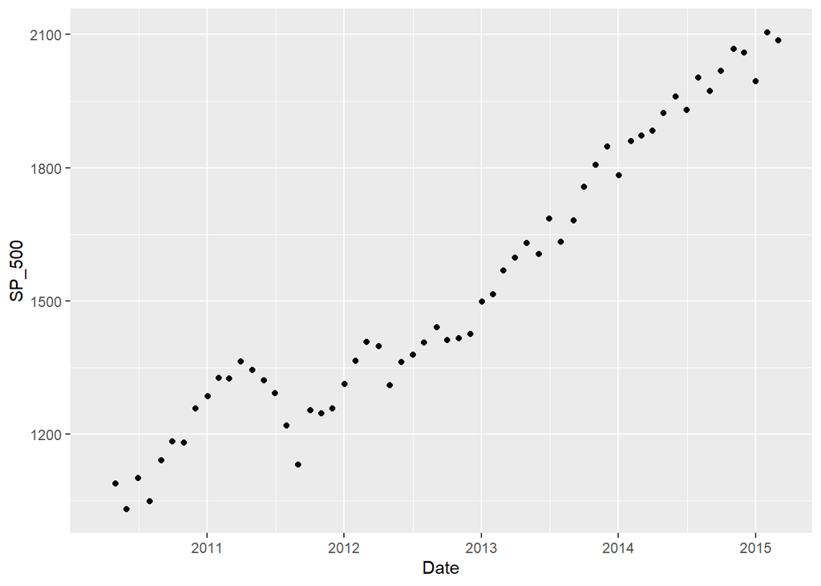

```r
stock$Date <- as.Date(stock$Date, format = "%m/%d/%Y")

ggplot(stock, aes(Date, SP_500)) + geom_point()
```

Now we will find the difference between months, setting the first date as the beginning of our timeline, get elapsed time as our x - axis.

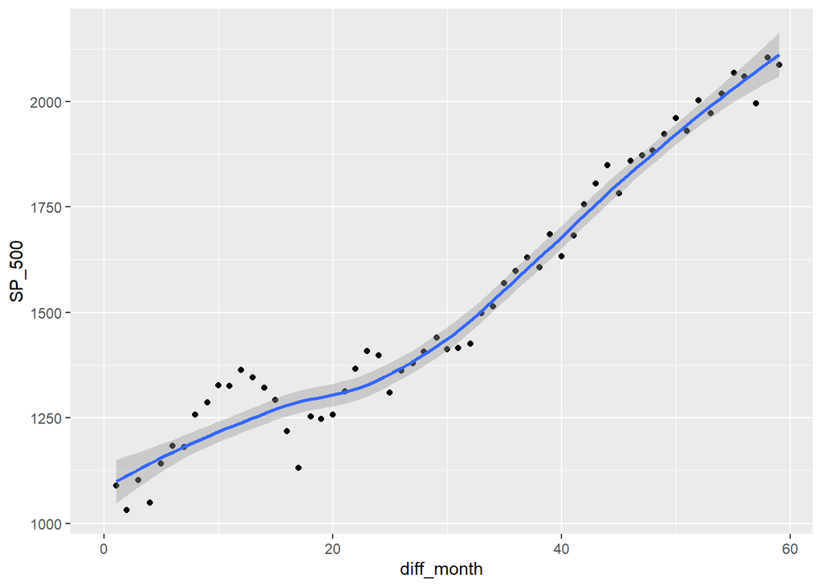

```r
begin <- stock$Date[1]

stock$diff_month <- sapply(stock$Date, FUN = function(x){interval(begin,x)/months(1)})

ggplot(stock, aes(diff_month, SP_500)) + geom_point() + stat_smooth()
```

## Analysis

Now, we will clean our data by checking if there are missing values in both predictors and responses.

```r
summary(stock$SP_500)
```

```
##    Min. 1st Qu.  Median    Mean 3rd Qu.    Max.    NA's
##    1031    1301    1416    1532    1827    2104       1
```

```r
which(is.na(stock$SP_500))
```

```
## [1] 1
```

```r
sum(is.na(stock$diff_month))
```

```
## [1] 0
```

Hence, there is only one missing value in our response SP_500 which is from the first observation

```r
set.seed(1)
inTrain <- createDataPartition(y = stock[-1, ]$SP_500, p = 0.75, list = FALSE)

training <- stock[inTrain, ]

testing <- stock[-inTrain,]
```

## Model evaluation

Now we will use linear regression for our training set to build our model for prediction

```r
train.fit <- lm(SP_500 ~ diff_month, data = training)
summary(train.fit)
```

```
##
## Call:
## lm(formula = SP_500 ~ diff_month, data = training)
##
## Residuals:
##     Min      1Q  Median      3Q     Max
## -158.81  -67.04   10.59   66.85  139.13
##
## Coefficients:
##             Estimate Std. Error t value Pr(>|t|)
## (Intercept) 983.3662    23.8370   41.25   <2e-16 ***
## diff_month   18.0510     0.7061   25.57   <2e-16 ***
## ---
## Signif. codes:  0 '***' 0.001 '**' 0.01 '*' 0.05 '.' 0.1 ' ' 1
##
## Residual standard error: 79.73 on 44 degrees of freedom
##   (1 observation deleted due to missingness)
## Multiple R-squared:  0.9369, Adjusted R-squared:  0.9355
## F-statistic: 653.6 on 1 and 44 DF,  p-value: < 2.2e-16
```

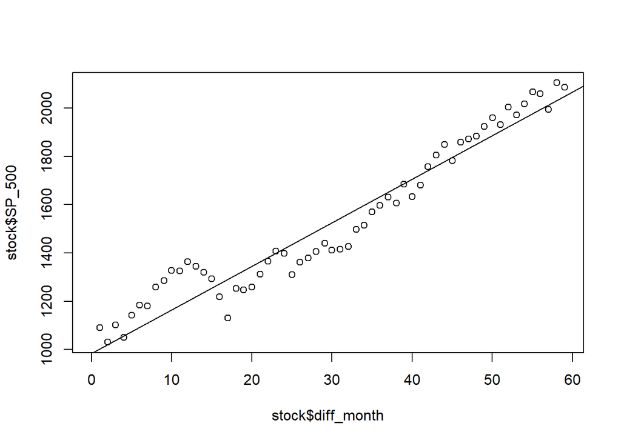

```r
plot(stock$diff_month, stock$SP_500)
abline(train.fit)
```

```r
summary(train.fit)
```

```
##
## Call:
## lm(formula = SP_500 ~ diff_month, data = training)
##
## Residuals:
##     Min      1Q  Median      3Q     Max
## -158.81  -67.04   10.59   66.85  139.13
##
## Coefficients:
##             Estimate Std. Error t value Pr(>|t|)
## (Intercept) 983.3662    23.8370   41.25   <2e-16 ***
## diff_month   18.0510     0.7061   25.57   <2e-16 ***
## ---
## Signif. codes:  0 '***' 0.001 '**' 0.01 '*' 0.05 '.' 0.1 ' ' 1
##
## Residual standard error: 79.73 on 44 degrees of freedom
##   (1 observation deleted due to missingness)
## Multiple R-squared:  0.9369, Adjusted R-squared:  0.9355
## F-statistic: 653.6 on 1 and 44 DF,  p-value: < 2.2e-16
```

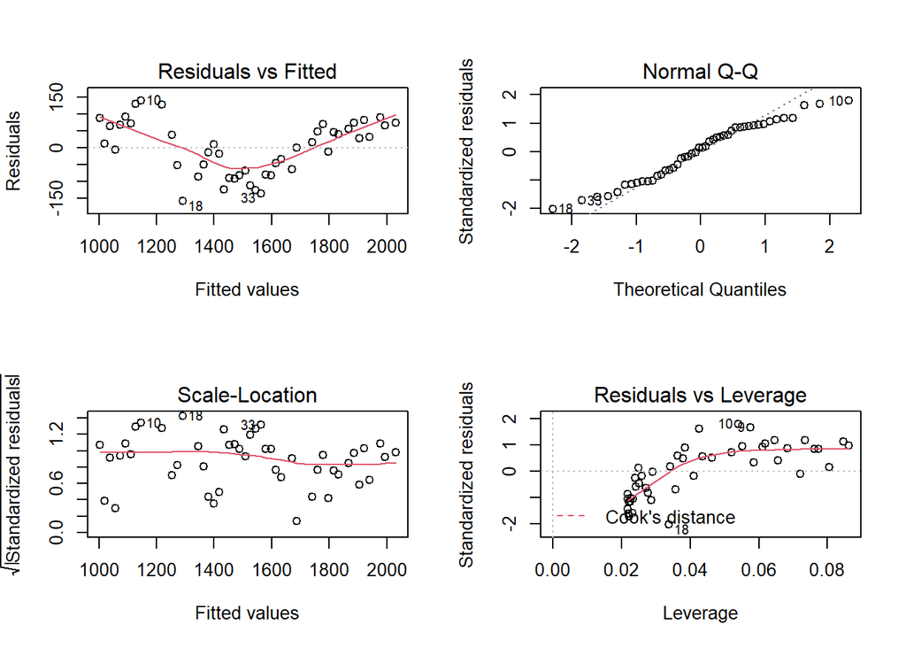

```r
par(mfrow=c(2,2))
plot(train.fit)
```

```r
par(mfrow=c(1,1))
```

From our summary fitting model, the coefficient is significant since both values have p-value much less than 0.05. The residual standard error is 79.73, R-Squared is 0.9369, meaning that our model fits the training set. Also, its F-statistic is 653.6, indicating that we can accept that our model fits the data better than the model with no independent variables The residuals follow are fairly normal distributed. Here, since no point falls outside of Cook’s distance (the red dashed lines) then no point is considered to be influential observation.

Now we will use this model to predict the testing set.

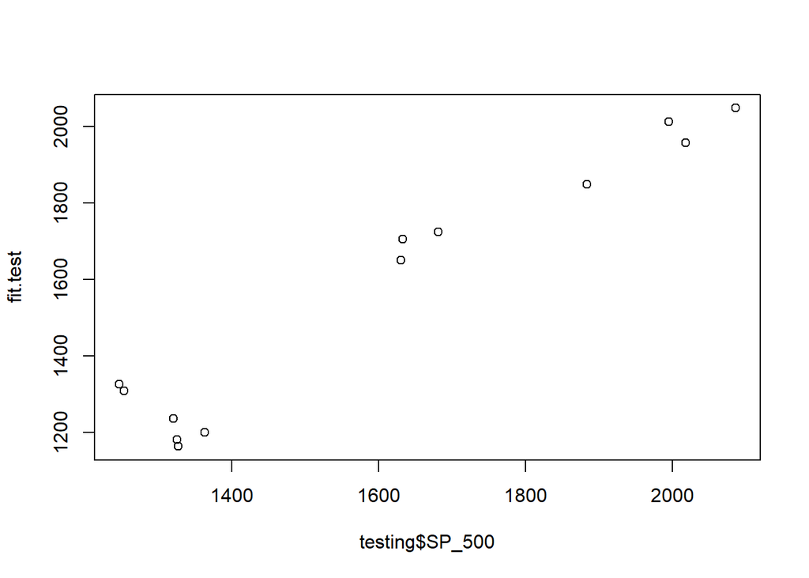

```r
fit.test <- predict(train.fit, testing)

plot(testing$SP_500, fit.test)
```

Here is the actual response SP_500 vs the fitted value SP_500

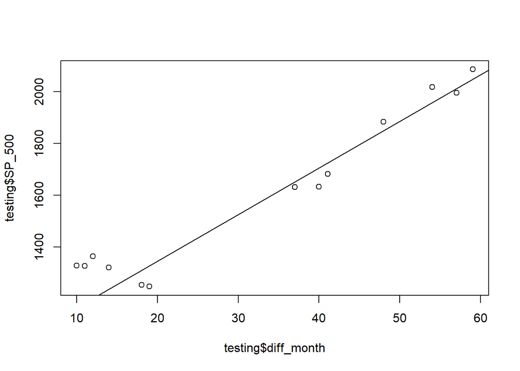

```r
{plot(testing$diff_month,testing$SP_500)
abline(train.fit)
}
```

## Reference

Link to the dataset [Link](https://regressit.com/Stock_returns_with_analysis.xlsx)